# Survival Curves from DHIS2 Tracker Data

Brian O’Donnell

5/6/2021

```r
knitr::opts_chunk$set(echo=TRUE, include=TRUE, message=TRUE,
                      warning=FALSE, paged.print=FALSE, fig.width = 7)

##Important!! Enter credential information. Include last "/" of the baseurl
##ENTER BASE URL, USERNAME, PASSWORD
baseurl<-params$baseurl
username<-params$username

##Load required packages
required_packages<-c("tidyverse","httr","assertthat","readr","knitr",
                    "tidyr","jsonlite", "keyring", "lubridate","survival","survminer",
                    "GGally","ggfortify")


is_installed <- function(mypkg) is.element(mypkg, installed.packages()[,1])

load_or_install<-function(required_packages) {
  for(package_name in required_packages)  {
    if(!is_installed(package_name))     {
       install.packages(package_name)  }
    library(package_name,character.only=TRUE,quietly=TRUE,verbose=FALSE)
  }
}

load_or_install(required_packages)
```

# From HIV Case Surveillance in DHIS2 to Kaplan-Meier Curves in R

The WHO [HIV Case Based surveillance metadata package](https://dhis2.org/who-package-downloads#hiv) can be used to capture patient-level data on ART regimens over time, including date of ART initiation and patient status. However, DHIS2 analytics are not advanced enough to build Cox Proportional Hazards models, or **survival curves** like below. These can be done in R with the `survminer` and `survival` packages.

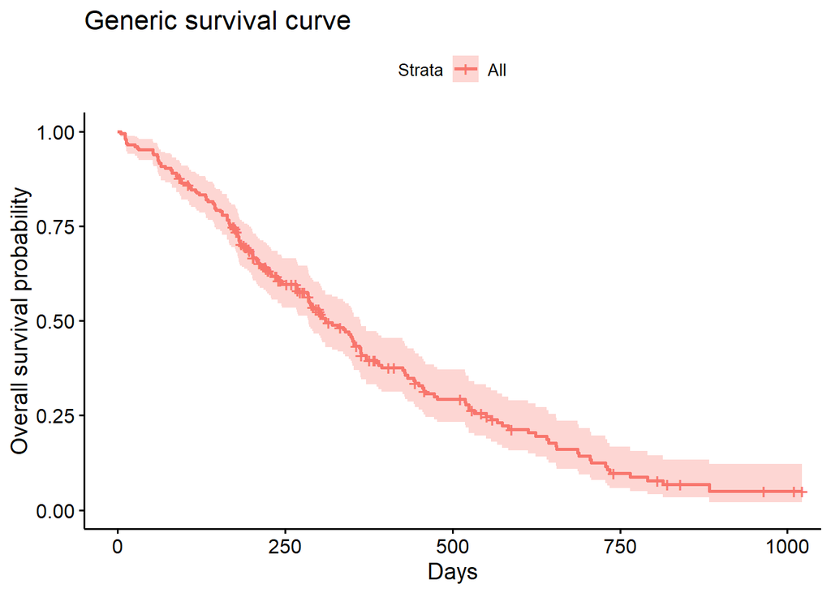

```r
ggsurvplot(
    fit = survfit(Surv(time, status) ~ 1, data = lung),
    xlab = "Days",
    ylab = "Overall survival probability",
    title="Generic survival curve")
```

This demo will show how to download the DHIS2 Event Reports required to build survival curves in an RMarkdown report.

## Enrollment Line Listing

Data have been collected from a demo DHIS2 database that uses the [WHO metadata package](https://who.sandbox.dhis2.org/HIV/) for HIV case surveillance.

This [event report](https://who.sandbox.dhis2.org/HIV/dhis-web-event-reports/?id=A5VXDAx9PGM) shows the latest Visit stage for all enrollments from the past 5 years and present year.

The variables included are…

- **Gender** : Tracked Entity Attribute for patient (options: Male, Female, Transgender)
- **Days since Treatment Start** : Enrollment-type program indicator calculating days between ART initiation date and the *latest Visit recorded* (repeatable stage) for each patient
- **PLHIV with Viral Load Suppression** : Data element for patient viral load <1000 copies/ml (suppressed) as of latest visit
- **Treatment Status** : Data element for patient status as of latest visit (options: On ART, Death Reported, Transferred, Stopped Treatment, Lost to Follow Up)

## Import Data

Two ways to import the data: download and then read CSV, or import directly through API.

To download the event report, go to **Download** > **CSV**

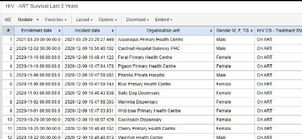

Data from the export could be then read into R for analysis with the `readr::read_csv()` function.

To import **through DHIS2 API**, the first thing to do is to enter credentials. On the first time running this script, you will be asked for a password to log-in to the demo system.

Once the `keyring` package stores and encrypts the password as a local environment variable, you can comment out that password set function Next time you run the script on this machine, you will not need to enter the password.

Using the API in this way allows for more process automation: run the script once, and later you can execute it routinely with a Cron job to access and publish the latest data.

```r
#youll now be prompted for password
# if you hav already set the password with keyring, you can comment this out
# keyring::key_set("Password", username=username)

##test login
loginDHIS2<-function(baseurl,username,password) {
  url<-paste0(baseurl,"api/me")
  r<-GET(url,authenticate(username,
                          keyring::key_get("Password", username=username)))
  warn_for_status(r, task="log in")
  if(r$status_code == 200L){return(TRUE)}
  }

if(loginDHIS2(baseurl, username, password)==TRUE){
  print("successfully logged in")
}else{
  stop("could not log in! Please check url, username and password")
}
```

```
## [1] "successfully logged in"
```

The API request url from the event report is found when going to **Download > HTML** . Simply change the link’s extension from .html+css to .csv

More details about the DHIS2 API can be found in the [DHIS2 Developer Guide](https://docs.dhis2.org/2.35/en/developer/html/dhis2_developer_manual_full.html)

`read_csv()` will show the columns imported and inferred column types

```r
url<-paste0(baseurl,
            "api/29/analytics/enrollments/query/Xh88p1nyefp.csv?", #enrollment query in CSV
          "dimension=pe:THIS_YEAR;LAST_5_YEARS", #this year and last 5
          "&dimension=ou:USER_ORGUNIT",#user orgunit
          "&dimension=Jt68iauILtD", #Gender attribute
          "&dimension=ang4CLldbIu.S4IJiirQVHY", # VL test result
          "&dimension=ang4CLldbIu.JyeF0Utlhfp:GT:1&", #days since ART > 1 (follow up visit)
          "&dimension=ang4CLldbIu.rcUsYgOnlyF",  # latest status
          "&stage=ang4CLldbIu&displayProperty=NAME", #identify stage and the displayName
          "&tableLayout=true&dataIdScheme=NAME", #use name of DE
          "&columns=pe;ou;Jt68iauILtD;JyeF0Utlhfp;S4IJiirQVHY;rcUsYgOnlyF", #table layout
          "&rows=pe;ou;Jt68iauILtD;JyeF0Utlhfp;S4IJiirQVHY;rcUsYgOnlyF&paging=false")


# function to fetch data from API
dta<-read_csv(httr::content(GET(url)))
```

## Cleaning Data

When cleaning the data, observations are considered **CENSORED** if the latest visit status was **On ART** or **Transferred Out**. That means the patient did not die or stop treatment before the end of the observation period.

```r
CS_data<-dta %>%
  janitor::clean_names() %>% ## clean variable names
  select(contains("enrollment"), contains("gender"),
         contains("viral"), contains("treatment")) %>% ## select vars
  rename("gender"=3, "vl_suppressed"=4, "days_since_start"=5,"status"=6) %>%
  filter(status!="NA") %>%  # remove NA#
  mutate(vl_suppressed=if_else(is.na(vl_suppressed),0,1)) %>%  # replace Na with 0
  mutate(censored=if_else(str_detect(status,c("ART|Transfer")), 1, 2))
# censor iff latest status On ART or transfer, otherwise status implies death/ltfu


#show first rows...
head(CS_data) %>%
  kable()
```

| enrollment | enrollment_date | gender | vl_suppressed | days_since_start | status | censored |
| --- | --- | --- | --- | --- | --- | --- |
| sN4rsb88a5H | 2020-02-12 | Male | 0 | 414 | On ART | 1 |
| TdDo0b6IZg3 | 2020-10-25 | Female | 0 | 189 | On ART | 1 |
| T7epRIGcG00 | 2021-03-11 | Female | 0 | 29 | On ART | 1 |
| LH2ZsCJZxQv | 2019-12-26 | Female | 0 | 497 | On ART | 1 |
| bBKF1KYului | 2019-08-25 | Transgender | 1 | 584 | On ART | 1 |
| Pu1jPvNWMYy | 2020-01-10 | Transgender | 1 | 455 | On ART | 1 |

## Summaries of variables

```r
##summarize data
CS_data %>%
  select(enrollment_date,days_since_start) %>%
  # split(.$status) %>%
  map(summary)
```

```
## $enrollment_date
##                  Min.               1st Qu.                Median
## "2018-12-02 00:00:00" "2019-05-23 00:00:00" "2019-11-06 00:00:00"
##                  Mean               3rd Qu.                  Max.
## "2019-11-20 03:47:41" "2020-04-03 00:00:00" "2021-04-23 00:00:00"
##
## $days_since_start
##    Min. 1st Qu.  Median    Mean 3rd Qu.    Max.
##    10.0   268.0   497.0   480.3   675.0  1027.0
```

```r
##count by latest status
CS_data %>%
  select(vl_suppressed, gender, status) %>%
  map(summary.factor)
```

```
## $vl_suppressed
##    0    1
## 2287 7326
##
## $gender
##      Female        Male Transgender
##        5443        3772         398
##
## $status
##          Death (documented)           Lost to follow up
##                         369                         335
##                      On ART Refused (stopped) treatment
##                        8159                         232
##             Transferred out
##                         518
```

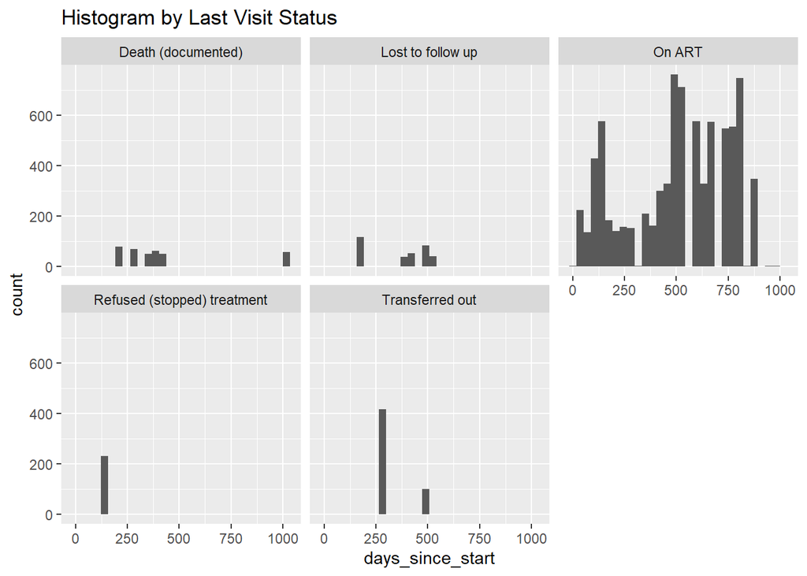

```r
## histogram
CS_data %>%
  ggplot()+
  geom_histogram(aes(days_since_start))+
  facet_wrap(~status) + ## histogram by status
  labs(title="Histogram by Last Visit Status")
```

## Specify Survival Function

Basic model without covariates, basic plot.

```r
km_fit<-survfit(Surv(days_since_start, censored) ~ 1,
                 data=CS_data,
                 type="kaplan-meier")

km_fit
```

```
## Call: survfit(formula = Surv(days_since_start, censored) ~ 1, data = CS_data,
##     type = "kaplan-meier")
##
##       n  events  median 0.95LCL 0.95UCL
##    9613     936    1027      NA      NA
```

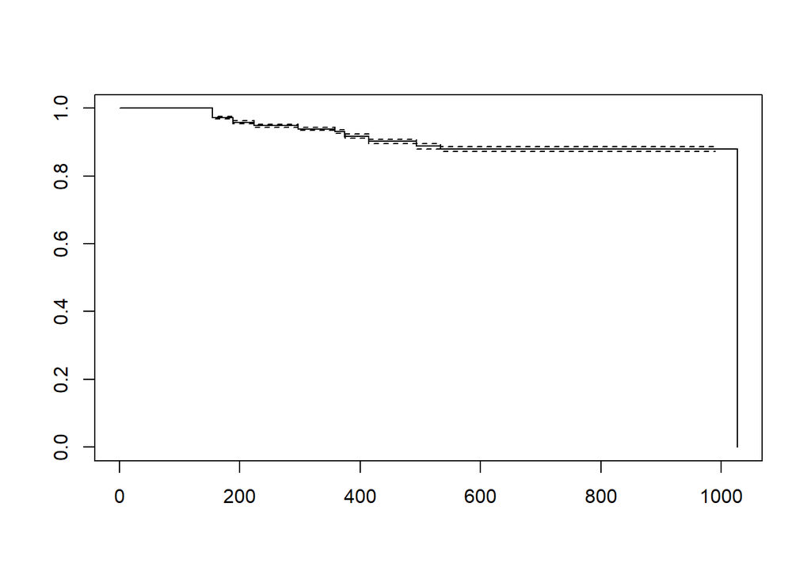

```r
plot(km_fit)
```

## Add Covariates

### Group by Gender

```r
km_fit1<-survfit(Surv(days_since_start, censored) ~ gender,
                 data=CS_data,
                 type="kaplan-meier")

km_fit1
```

```
## Call: survfit(formula = Surv(days_since_start, censored) ~ gender,
##     data = CS_data, type = "kaplan-meier")
##
##                       n events median 0.95LCL 0.95UCL
## gender=Female      5443    502   1027      NA      NA
## gender=Male        3772    396   1027      NA      NA
## gender=Transgender  398     38     NA      NA      NA
```

```r
# summary(km_fit1)
```

### Group by VL Suppression

```r
km_fit2<-survfit(Surv(days_since_start, censored) ~ vl_suppressed,
                 data=CS_data,
                 type="kaplan-meier")

km_fit2
```

```
## Call: survfit(formula = Surv(days_since_start, censored) ~ vl_suppressed,
##     data = CS_data, type = "kaplan-meier")
##
##                    n events median 0.95LCL 0.95UCL
## vl_suppressed=0 2287    350     NA      NA      NA
## vl_suppressed=1 7326    586   1027      NA      NA
```

## Plot Survival Curve

the Kaplan-Meier model is plotted with the `survminer` R package.

Code adapted from: http://www.sthda.com/english/wiki/survminer-0-3-0

**NB! These models are based on case surveillance dummy data and are for demonstration purposes only**

### By Gender

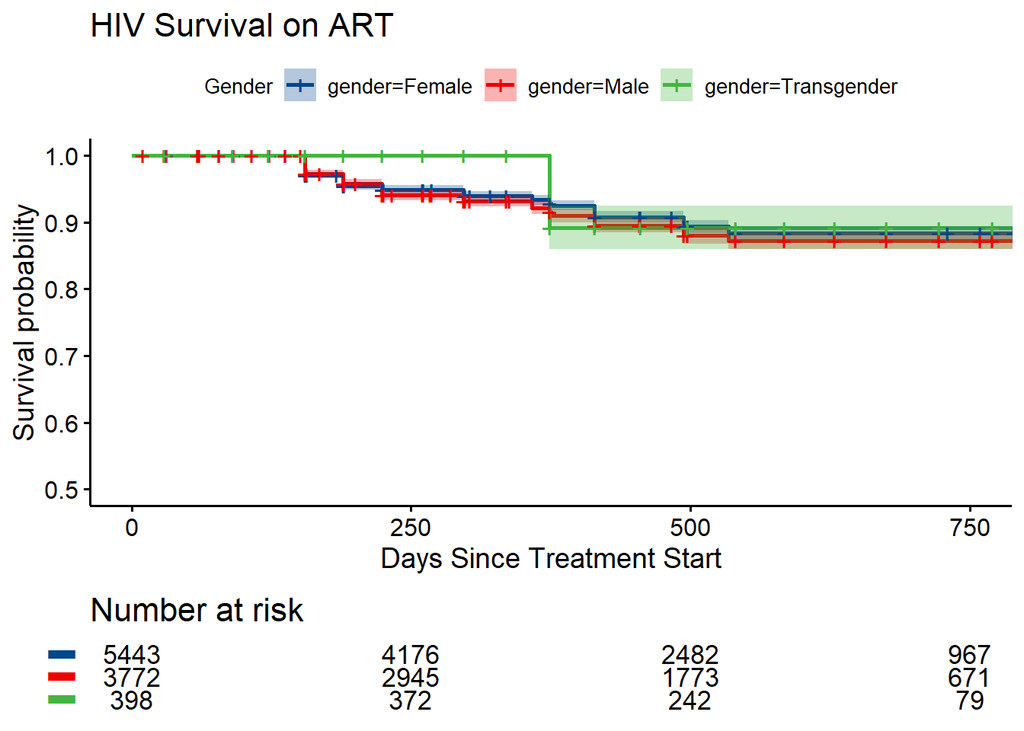

```r
# fit <- survfit(Surv(time, status) ~ sex, data = lung)

plotObj<-ggsurvplot(km_fit1, data = CS_data,
           title = "HIV Survival on ART",
           pval = TRUE, pval.method = TRUE,    # Add p-value &  method name
           legend.title = "Gender",  # Change legend titles
           palette = "lancet",                 # Use JCO journal color palette
           risk.table = TRUE,                  # Add No at risk table
           # cumevents = TRUE,                   # Add cumulative No of events table
           tables.height = 0.2,               # Specify tables height
           tables.theme = theme_cleantable(),  # Clean theme for tables
           tables.y.text = FALSE,              # Hide tables y axis text
           xlab = "Days Since Treatment Start",
           conf.int = TRUE,
           xlim = c(0,750),
           ylim = c(0.5,1)
)

# Now save the plot image
# ggsave("survivalplot.png", print(plotObj))

plotObj
```

### By VL Suppression

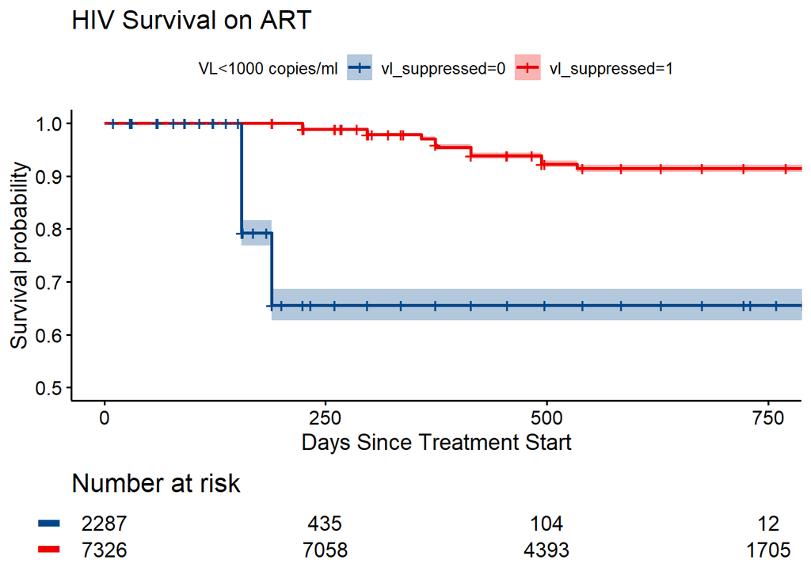

```r
# fit <- survfit(Surv(time, status) ~ sex, data = lung)

plotObj<-ggsurvplot(km_fit2, data = CS_data,
           title = "HIV Survival on ART",
           pval = TRUE, pval.method = TRUE,    # Add p-value &  method name
           legend.title = "VL<1000 copies/ml",            # Change legend titles
           palette = "lancet",                 # Use JCO journal color palette
           risk.table = TRUE,                  # Add No at risk table
           # cumevents = TRUE,                   # Add cumulative No of events table
           tables.height = 0.2,               # Specify tables height
           tables.theme = theme_cleantable(),  # Clean theme for tables
           tables.y.text = FALSE,              # Hide tables y axis text
           xlab = "Days Since Treatment Start",
           conf.int = TRUE,
           xlim = c(0,750),
           ylim = c(0.5,1)
)

# Now save the plot image
ggsave("survivalplot.png", print(plotObj))
plotObj
```

## More models

### Comparing survival times between groups

```r
survdiff(Surv(days_since_start, censored) ~ gender,
                 data=CS_data)
```

```
## Call:
## survdiff(formula = Surv(days_since_start, censored) ~ gender,
##     data = CS_data)
##
##                       N Observed Expected (O-E)^2/E (O-E)^2/V
## gender=Female      5443      502    521.4     0.721     1.763
## gender=Male        3772      396    371.5     1.621     2.915
## gender=Transgender  398       38     43.1     0.613     0.656
##
##  Chisq= 3.2  on 2 degrees of freedom, p= 0.2
```

### Cox regression model

Comparing to VL non-suppressed

```r
broom::tidy(
  coxph(Surv(days_since_start, censored) ~ vl_suppressed,
        data = CS_data),
  exp = TRUE) %>%
  kable()
```

| term | estimate | std.error | statistic | p.value |
| --- | --- | --- | --- | --- |
| vl_suppressed | 0.101974 | 0.0713021 | -32.0192 | 0 |

## Next Steps

### Other Analysis Workflows

- Include other covariates, such as mode of transmission, age range, or CD4 count
- Compare survival curves for annual cohorts or by geography (district, clinic, etc)
- Use `Knitr` to turn [RMarkdown](https://rmarkdown.rstudio.com/) doc into an HTML webpage, PDF, or slide deck
- Run the script as a monthly CRON job to analyze latest data
- Save survival curve as PNG file, share in report

*Or… import CSV from DHIS2 into your choice of software e.g. STATA, SPSS*

### Other Resources for Survival Analyses

- [Kaplan Meier Intro in R](https://rmvpaeme.github.io/KaplanMeier_intro/)
- [Survminer package](http://www.sthda.com/english/wiki/survminer-r-package-survival-data-analysis-and-visualization)
- [Survival Analysis in R](https://www.emilyzabor.com/tutorials/survival_analysis_in_r_tutorial.html) (More in depth than above)